# chapter-6

Probability

## Probability

A number that represents the likelihood an event will occur.

$$p(A) = \frac {The \, number \, of \, times \, A \, can \, occur}{The \, total \, number \, of \, possible \, outcomes}$$

## Probabiltity vs Proportion

Probability

- Represents the chance of some event occurring
- Theoretical
- Event has not occurred

Proportion

- Summarizes how frequently some event actually occurred
- Empirical
- Event has occurred

## Probabiltity vs Proportion Coin Example

If we flip a fair coin, the probability that it lands on heads is 1/2 or 50%.

But if we flip a coin 20 times and count the number of times it lands on heads, lets say 12 times, then our proportion is 12/20 or 60%.

[figure not shown]

## Coin Example

Let’s flip some coins!

## Card Example

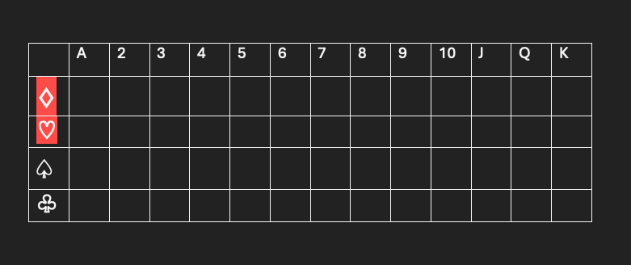

# Discrete Probability

## Discrete Probability

A type of probability that deals with the likelihood an event will occur within a finite (limited) possible outcomes.

Binomials

Trials (i.e., an act with an different outcomes) that have exactly two possible outcomes.

- Coin flips
- Chances of success for a free-throw shooter in basketball, where 1 = a basket made and 0 = a miss.

Binomial probability distribution contains all the possible results over a set of trials and lists the probability of each result.

## The Binomial Coefficient and the Probability Distribution

Criteria

1.) Fixed Trials

2.) Independent Trials

3.) Fixed Probability of Success

4.) Two Mutuallly Exclusive Outcomes

## The Binomial Coefficient and the Probability Distribution

$$p(x) = \binom{n}{x}p^xq^{n-x}$$

p(x) = probability of x occurring

x = number of successes

n = sample size

p = probability event will occur

q = probability event will not occur

## Breakdown of “n choose x”

$$\binom{n}{x} = \frac{n!}{x!(n-x)!}$$

n = sample size  
x = number of successes  
! = factorial

## What is q?

p = probability event will occur  
q = probability event will not occur

## Example

Do people prefer Qdoba or Chipotle? Let’s say asked three people what they prefer.

## Example

But we are conditioning on order here.

0.5 * 0.5 * 0.5 = 0.125

0.5 * 0.5 * 0.5 = 0.125

0.5 * 0.5 * 0.5 = 0.125

0.125 + 0.125 + 0.125 = ?

## Let’s work the formula

Do people choose Qdoba or Chipotle? Let’s say asked 3 people what they prefer (with a probability (p) of 0.50 for choosing Qdoba) - 2 people chose Qdoba and 1 chose Chipotle.

What is the probability that people preferred Qdoba?

$$p(x) = (\frac{n!}{x!(n-x)!})p^x(1-p)^{n-x}$$
x = ?

n = ?

p = ?

## Let’s attack our ‘n choose x’ first

$$\binom{n}{x} = \frac{n!}{x!(n-x)!}$$

$$\binom{3}{2} = \frac{3!}{2!(3-2)!}$$

$$\frac{6}{2}=3$$

## Let’s continue

$$p(x) = (3)p^xq^{n-x}$$

$p^x$ is the probability that Qdoba was chosen 2 out of 3 times.

## Let’s continue

$$p(x) = (3)0.5^2(1-p)^{n-x}$$

1.) This is the probability that someone will prefer Chipolte

$$(1 - 0.50) = 0.50$$

2.) This corresponds to the one person that preferred Chipotle

$$(3 - 2) = 1$$

## Final Version

Before simplified:

$$p(x) = (\frac{3!}{2!(3-2)!})0.5^2(1-0.5)^{3-2}$$

Simplified:

$$p(x) = (3)(0.25)(0.5)$$

$$p(x) = 0.375$$

## Recap

The Binomial Coefficient or ‘n choose k’

$$\binom{n}{x} = \frac{n!}{x!(n-x)!}$$

The Binomial Probability Distribution

$$p(x) = (\frac{n!}{x!(n-x)!})p^x(1-p)^{n-x}$$

Now that we covered the surface of binomial distributions, let’s dig a little deeper, with multiple binomial coefficient calculations.

## Lets review exponent rules

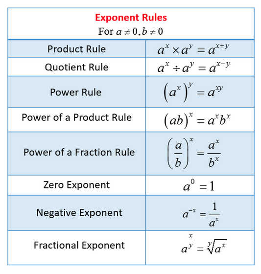

image: online math learning

## Example 2

Let’s imagine there are 4 Formula-1 races that will occur in June and July, Max Verstappen of Red Bull Racing has a 60% chance of winning.

Assuming that the races are independent of each other, what is the probability that he will win 0 races, 1 race, 2 races, 3 races, or all 4 races?

$$p(x) = (\frac{n!}{x!(n-x)!})p^x(1-p)^{n-x}$$

# Let’s break this down with 4 steps

## Step 1

What do we know?

n = 4 races

x = He will win: 0, 1, 2, 3, 4 races

p = 0.60

- Since x has multiple outcomes, we must calculate the binomial coefficient for each.

## Step 2

Calculate ‘n choose x’ for each x

- 0 $\binom{4}{0} = \frac{4!}{0!(4-0)!} = 1$
- 1 $\binom{4}{1} = \frac{4!}{1!(4-1)!} = 4$
- 2 $\binom{4}{2} = \frac{4!}{2!(4-2)!} = 6$
- 3 $\binom{4}{3} = \frac{4!}{3!(4-3)!} = 4$
- 4 $\binom{4}{4} = \frac{4!}{4!(4-4)!} = 1$

$$\binom{n}{x} = \frac{n!}{x!(n-x)!}$$

## Step 3

Plug in and solve the rest

- $(1)0.60^0(1-0.60)^{4-0} = 0.0256$
- $(4)0.60^1(1-0.60)^{4-1} = 0.1536$
- $(6)0.60^2(1-0.60)^{4-2} = 0.3456$
- $(4)0.60^3(1-0.60)^{4-3} = 0.3456$
- $(1)0.60^4(1-0.60)^{4-4} = 0.1296$

$$(Step\,2)\,p^xq^{n-x}$$

## Step 4

Summarize the result

Max Verstappen has a …

2.56% chance to win 0 races.

15.36% chance to win 1 races.

34.56% chance to win 2 races.

34.56% chance to win 3 races.

12.96% chance to win 4 races.

[figure not shown]

Image: NBC Sports

# Continuous Probability: The Standard Normal Curve

## Standard Normal Curve

Sometimes our distribution can have a lot of variance and thus can result in varying levels of kurtosis.

To compensate for this, we can standardize our scores by apply a z-score.

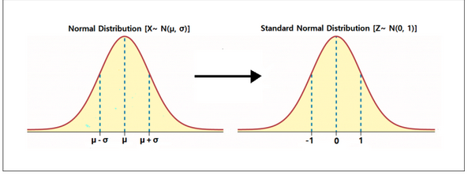

image: Math is fun

## Z-Score

Tells you how many standard deviations a specific point is away from the mean of a distribution.

Positive z-score: A positive z-score indicates that the value (x) lies above the mean by a certain number of standard deviations.

Negative z-score: A negative z-score indicates that the value (x) lies below the mean by a certain number of standard deviations.

Zero z-score: A z-score of 0 means the value (x) is exactly equal to the mean of the data set.

## Z-Score

$$z = \frac{x - \bar{x}}{\sigma}$$

$x$ = Raw score  
${\bar{x}}$ = Sample mean  
${\sigma}$ = Standard deviation

## Z-Score Example

Imagine you have a class of 20 students and you give them a math test. The mean was 75 points, and the standard deviation (SD) is (+/-) 10 points.

One student scored 88 points on the test. Calculate the z-score for the student.

$$z = \frac{x - \bar{x}}{\sigma}$$

## Z-Score Example

$$z = \frac{88 - 75}{10}$$
$$z = 1.30$$

The score is 1.30 standard deviations above the mean.

In other words, the student preformed better than 1.30 standard deviations compared to the average score in the class.

## Have a Great Weekend!

[figure not shown]

giphy